# Projet Analyse Statistique

Skander Ben Sedrine / Mohamed Mourad Aouadi / Olfa Jabeur / Basma Abid

2022-12-03

## Importation et exploration des données R

**1- Importation du jeu de données ‘Heart’**

```r
bd <- read.delim("/Users/skanderbensedrine/Desktop/Cours/Proba statistiques/Projet Analyse Statistiques/Projet_analyse_statistique/Heart .txt", header = TRUE, sep = "\t")
```

**2- Afficher les noms des variables et décrire ce jeu de données. Lister toutes les variables avec leurs types et modalités. Interpréter.**

*2.A : Liste de toutes les variable, leur types et leur modalités.*

```r
str(bd)
```

```
## 'data.frame':    270 obs. of  13 variables:
##  $ age         : int  70 67 57 64 74 65 56 59 60 63 ...
##  $ sexe        : chr  "masculin" "feminin" "masculin" "masculin" ...
##  $ type_douleur: chr  "D" "C" "B" "D" ...
##  $ pression    : int  130 115 124 128 120 120 130 110 140 150 ...
##  $ cholester   : int  322 564 261 263 269 177 256 239 293 407 ...
##  $ sucre       : chr  "A" "A" "A" "A" ...
##  $ electro     : chr  "C" "C" "A" "A" ...
##  $ taux_max    : int  109 160 141 105 121 140 142 142 170 154 ...
##  $ angine      : chr  "non" "non" "non" "oui" ...
##  $ depression  : num  2.4 1.6 0.3 0.2 0.2 0.4 0.6 1.2 1.2 4 ...
##  $ pic         : int  2 2 1 2 1 1 2 2 2 2 ...
##  $ vaisseau    : chr  "D" "A" "A" "B" ...
##  $ coeur       : chr  "presence" "absence" "presence" "absence" ...
```

*Nous pouvons coustater que notre jeu de données contient au total 13 Variables, Les modalités de chaque variable sont correctement affichées, par contre R n’affiche pas correctement le Type de ces variables , ils nous affiche uniquement si chaque colonne contient des entiers ou une chaine de caractères (int/chr).La seule variable affichée correctement c’est la variable “Depression” qui est une variable quantitative continue de type “numeric/num”.*

*2.B : Description des données -> Affichage des 6 premières et derniere lignes de notre jeu de données.*

```r
head(bd)
```

```
##   age     sexe type_douleur pression cholester sucre electro taux_max angine
## 1  70 masculin            D      130       322     A       C      109    non
## 2  67  feminin            C      115       564     A       C      160    non
## 3  57 masculin            B      124       261     A       A      141    non
## 4  64 masculin            D      128       263     A       A      105    oui
## 5  74  feminin            B      120       269     A       C      121    oui
## 6  65 masculin            D      120       177     A       A      140    non
##   depression pic vaisseau    coeur
## 1        2.4   2        D presence
## 2        1.6   2        A  absence
## 3        0.3   1        A presence
## 4        0.2   2        B  absence
## 5        0.2   1        B  absence
## 6        0.4   1        A  absence
```

```r
tail(bd)
```

```
##     age     sexe type_douleur pression cholester sucre electro taux_max angine
## 265  48 masculin            B      110       229     A       A      168    non
## 266  52 masculin            C      172       199     B       A      162    non
## 267  44 masculin            B      120       263     A       A      173    non
## 268  56  feminin            B      140       294     A       C      153    non
## 269  57 masculin            D      140       192     A       A      148    non
## 270  67 masculin            D      160       286     A       C      108    oui
##     depression pic vaisseau    coeur
## 265        1.0   3        A presence
## 266        0.5   1        A  absence
## 267        0.0   1        A  absence
## 268        1.3   2        A  absence
## 269        0.4   2        A  absence
## 270        1.5   2        D presence
```

**3- Determiner si le jeu de données contient des valeurs manquantes ou pas.**

```r
sum(is.na(bd))
```

```
## [1] 0
```

*Nous Pouvons Constater que notre jeu de données ne contient aucune valeurs manquante.*

**4- Préciser les modalités de chacune de ces variables ainsi que l’effectif de chacune après avoir procéder aux changements nécessaires.**

*4.1 : Changement du Type des Variables*

```r
bd$electro <- as.ordered(bd$electro) #Variable Qualitative ordinale
bd$coeur <- factor(bd$coeur) #Variable Qualitative nominale

str(bd$electro) #Vérification du changement de type de la variable Electro
```

```
##  Ord.factor w/ 3 levels "A"<"B"<"C": 3 3 1 1 3 1 3 3 3 3 ...
```

```r
str(bd$coeur) #Vérification du changement de type de la variable Coeur
```

```
##  Factor w/ 2 levels "absence","presence": 2 1 2 1 1 1 2 2 2 2 ...
```

*4.2 : Affichage des modalités et de l’effectif de chaque variable*

```r
levels(bd$electro) #Affiche Les modalités de la variable Electro
```

```
## [1] "A" "B" "C"
```

```r
table(bd$electro) #Affiche L'effectif de la variable Electro
```

```
##
##   A   B   C
## 131   2 137
```

```r
levels(bd$coeur) #Affiche Les modalités de la variable Coeur
```

```
## [1] "absence"  "presence"
```

```r
table(bd$coeur) #Affiche L'effectif de la variable Coeur
```

```
##
##  absence presence
##      150      120
```

**5.1 : Calculer la fréquence relative de chacune de ces variables.**

*Fréquence Relative de la variable Electro :*

```r
Freq_relative_Age <- prop.table(table(bd$electro)) / nrow(bd)
format(Freq_relative_Age, scientific = F)
```

```
##
##               A               B               C
## "0.00179698217" "0.00002743484" "0.00187928669"
```

*Fréquence Relative de la variable Coeur :*

```r
Freq_relative_Coeur <- prop.table(table(bd$coeur)) / nrow(bd)
Freq_relative_Coeur
```

```
##
##     absence    presence
## 0.002057613 0.001646091
```

**5.2 : Représenter graphiquement chaque variable de deux façons différentes. Mettez les graphiques sur un même plot.**

*Représentation graphique de la variable Electro :*

Diagramme en bâtons / Camembert

Chargement du package ggplot2 pour une visualisation attractive, et du package gridExtra pour afficher plusieurs graphiques sur une page.

```r
library(ggplot2)
library(gridExtra)
```

Chargement du Package gridExtra pour afficher plusieurs graphiques sur une page

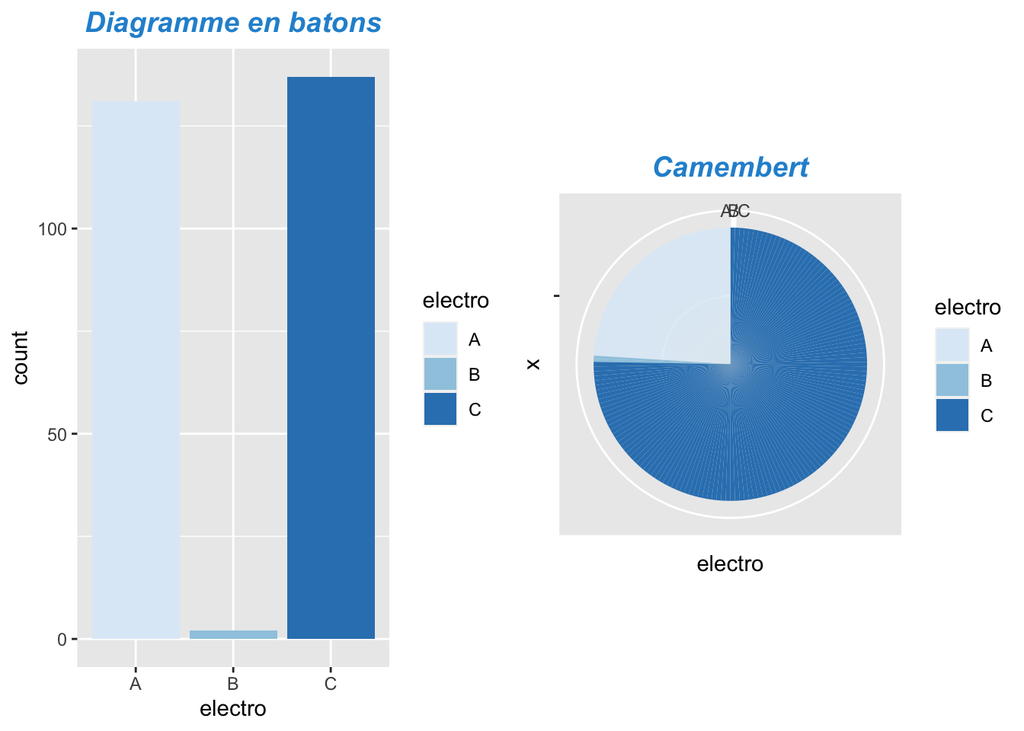

```r
diag1 <- ggplot(bd)+aes(x=electro)+geom_bar(aes(fill = electro)) + scale_fill_brewer(palette="Blues") + ggtitle("Diagramme en batons") + theme(
plot.title = element_text(color="#2692D4", size=14, face="bold.italic", hjust = 0.5))

cam1 <- bp<- ggplot(bd, aes(x="", y=electro, fill=electro))+
geom_bar(width = 1, stat = "identity") + coord_polar("y", start=0) + scale_fill_brewer(palette="Blues") + ggtitle("Camembert") + theme(
plot.title = element_text(color="#2692D4", size=14, face="bold.italic", hjust = 0.5))

grid.arrange(diag1,cam1, ncol = 2)
```

*Représentation graphique de la variable Coeur :*

Diagrame en bâtons / Camembert :

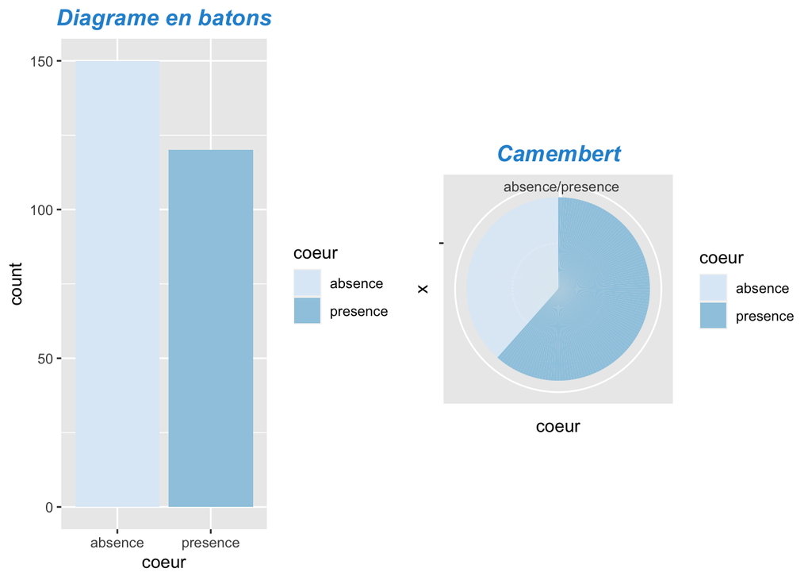

```r
diag2 <- ggplot(bd)+aes(x=coeur)+geom_bar(aes(fill = coeur)) + scale_fill_brewer(palette="Blues") + ggtitle("Diagrame en batons") + theme(
plot.title = element_text(color="#2692D4", size=14, face="bold.italic", hjust = 0.5))

cam2 <- bp<- ggplot(bd, aes(x="", y=coeur, fill=coeur))+
geom_bar(width = 1, stat = "identity") + coord_polar("y", start=0) + scale_fill_brewer(palette="Blues") + ggtitle("Camembert") + theme(
plot.title = element_text(color="#2692D4", size=14, face="bold.italic", hjust = 0.5))

grid.arrange(diag2,cam2, ncol = 2)
```

**6- Étudier le croisement entre ces deux variables :**

*Pour étudier le croisement entre ces deux variables, nous devons créer la table de contingence :*

```r
Table_contingence <- table(bd$electro,bd$coeur)
Table_contingence
```

```
##
##     absence presence
##   A      85       46
##   B       1        1
##   C      64       73
```

**7) Représenter à l’aide du graphique approprié ce croisement :**

*Representation à l’aide d’un mosaicplot :*

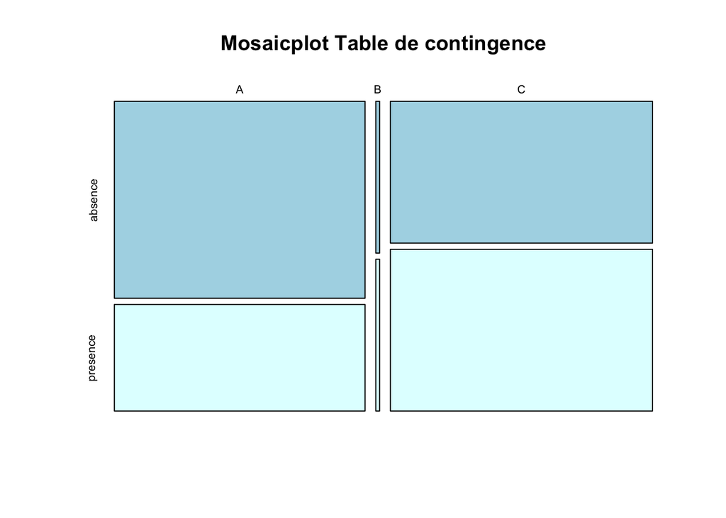

```r
plot_croisement <- mosaicplot(Table_contingence, col = c("lightblue","lightcyan"), main = "Mosaicplot Table de contingence")
```

*Representation à l’aide d’un barplot :*

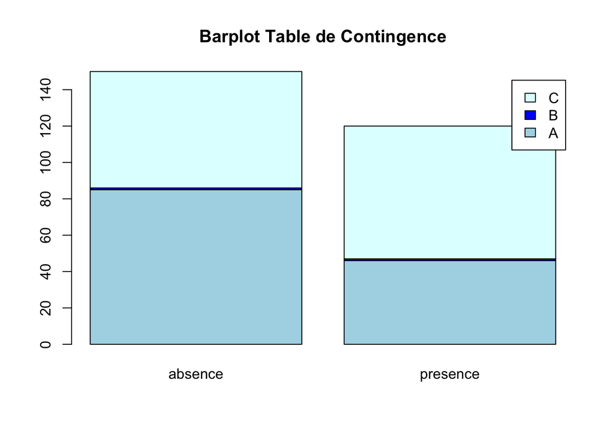

```r
plot_croisement2 <- barplot(Table_contingence, legend = rownames(Table_contingence), col = c("lightblue","blue","lightcyan"), main = "Barplot Table de Contingence")
```

**8- Appliquer le test Khi-2. Afficher le résultat et interpréter :**

*Test de Khi-2 :*

```r
chisq.test(Table_contingence)
```

```
##
##  Pearson's Chi-squared test
##
## data:  Table_contingence
## X-squared = 8.9795, df = 2, p-value = 0.01122
```

## Etude des variables “Age” et “Cholesterol”

**9- Déterminer les indicateurs statistiques usuels pour chacune des variables age et cholesterol (moyenne, médiane, quartile, min, max).**

*9.1 : indicateurs statistiques de la variable “age” :*

Changement de type de la variable age en type numeric (variable quantitative continue)

```r
bd$age <- as.numeric(bd$age)
```

Vérification du changement du type de la varibale age et affichage du résumé statistique

```r
str(bd$age)
```

```
##  num [1:270] 70 67 57 64 74 65 56 59 60 63 ...
```

```r
summary(bd$age)
```

```
##    Min. 1st Qu.  Median    Mean 3rd Qu.    Max.
##   29.00   48.00   55.00   54.43   61.00   77.00
```

*9.2 : indicateurs statistiques de la variable “cholesterol” :*

Changement de type de la variable cholester (variable quantitative continue)

```r
bd$cholester <- as.numeric(bd$cholester)
```

Vérification du changement du type de la varibale cholester et affichage du résumé statistique

```r
str(bd$cholester)
```

```
##  num [1:270] 322 564 261 263 269 177 256 239 293 407 ...
```

```r
summary(bd$cholester)
```

```
##    Min. 1st Qu.  Median    Mean 3rd Qu.    Max.
##   126.0   213.0   245.0   249.7   280.0   564.0
```

**10- Étudier la dispersion de chaque variable par rapport à la moyenne en calculant les paramètres appropriés. Interpréter en ce qui concerne l’homogéniété.**

*10.1 : étude de la dispersion de la variable “Age”*

```r
sd(bd$age) #calcul de l'écart-type
```

```
## [1] 9.109067
```

```r
sd(bd$age)/ mean(bd$age) * 100 #Calcul du coefficient de variation
```

```
## [1] 16.73435
```

Nous Pouvons constater que notre coefficient de variation n’est pas assez élevé (car ne dépasse pas les 20%) ce qui signifie que la distribution des données est homogène et que les données sont bien concentrés autour de la moyenne.

*10.2 : étude de la dispersion de la variable “Cholester”*

```r
sd(bd$cholester) #calcul de l'écart-type
```

```
## [1] 51.68624
```

```r
sd(bd$cholester)/ mean(bd$cholester) * 100 #Calcul du coefficient de variation
```

```
## [1] 20.70271
```

Pour notre variable “cholester”, notre coefficient de variation est assez élevé dépassant légerement les 20% ce qui signifie que la distribution des données n’est pas homogène et que les données sont mal dispersés autour de la moyenne.

**11- Tracer la boite à moustaches de chaque variable. Décrire minutieusement ce graphe. Commenter de point de vue dispersion des observations.**

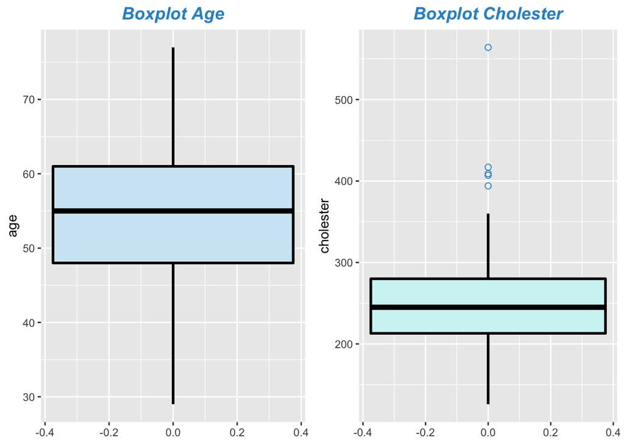

```r
p <- ggplot(bd, aes(x=age)) + coord_flip() +
  geom_boxplot(size = 1, fill='#D0E8F5', color="black") + ggtitle("Boxplot Age") + theme(
plot.title = element_text(color="#2692D4", size=14, face="bold.italic", hjust = 0.5))

p2 <- ggplot(bd, aes(x=cholester)) + coord_flip() +
  geom_boxplot(size = 1, outlier.colour="#2692D4", outlier.shape=1,
  outlier.size=2, fill='#D0F4F5', color="black") + ggtitle("Boxplot Cholester") + theme(
plot.title = element_text(color="#2692D4", size=14, face="bold.italic", hjust = 0.5))

grid.arrange(p,p2, ncol = 2)
```

Description : Nous pouvons constater que l’Age median de notre distribution est de 55 ans, et que l’age de la plupart des sujets est situé entre a peu prés 48 ans et 61 ans et que l’age minimum est de 29 ans et l’age maximum est de 77 ans. Cette distribution est normale et ne comporte aucunes valeurs aberrantes.

**12- On voudrait regrouper la variable âge en classes d’âges. Représenter graphiquement ces classes. Rappeler la règle utilisée pour obtenir le nombre de classes.**

Rappel : Pour obtenir le nombre de classes, il suffit d’ajouter le paramètre break pour une visualisation basique, ou le paramètre bins sur “ggplot2” et spécifier le nombre de classes.

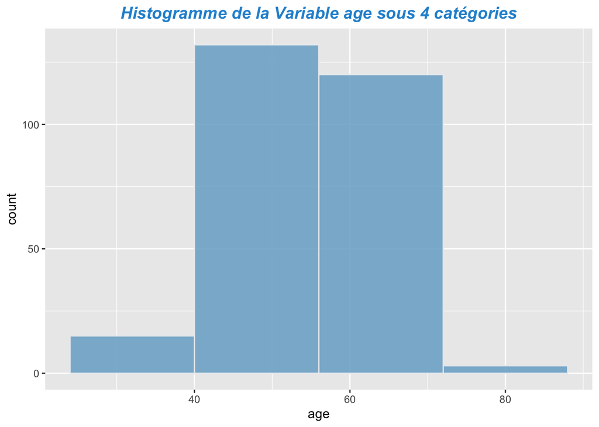

```r
ggplot(bd)+aes(x=age)+geom_histogram(bins=4, fill="#80B1CF", color="#e9ecef", alpha=0.9) +
    ggtitle("Histogramme de la Variable age sous 4 catégories") + theme(
plot.title = element_text(color="#2692D4", size=14, face="bold.italic", hjust = 0.5))
```

Représentation Graphique de la variable Cholester sous 6 catégories differentes :

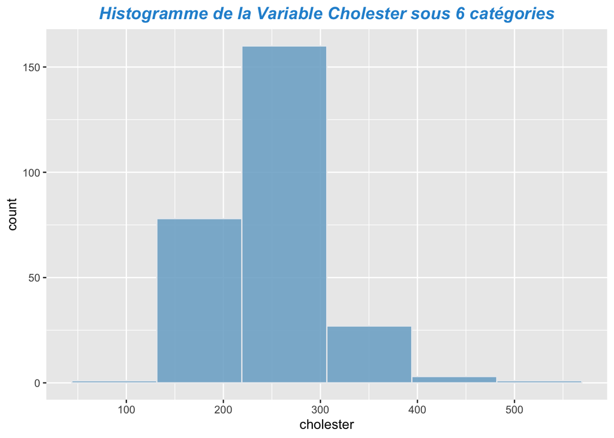

```r
ggplot(bd)+aes(x=cholester)+geom_histogram(bins=6, fill="#80B1CF", color="#e9ecef", alpha=0.9) +
    ggtitle("Histogramme de la Variable Cholester sous 6 catégories") + theme(
plot.title = element_text(color="#2692D4", size=14, face="bold.italic", hjust = 0.5))
```

**13- Quel est l’effectif correspondant à chaque classe ?**

Effectif de la classe Age :

```r
classe_age = cut(bd$age, c(20,40,60,80))
table(classe_age)
```

```
## classe_age
## (20,40] (40,60] (60,80]
##      15     183      72
```

Effectif de la classe Cholester :

```r
classe_cholester = cut(bd$cholester, c(100,200,300,400,500,600))
table(classe_cholester)
```

```
## classe_cholester
## (100,200] (200,300] (300,400] (400,500] (500,600]
##        40       189        37         3         1
```

**14- Maintenant on va passer à explorer la relation entre ces variables. Claculer la covariance ainsi que la corrélation entre ces deux variables. Interpréter**

Calcul de la covariance entre les deux variables Age et Cholester :

```r
cov(bd$age,bd$cholester)
```

```
## [1] 103.6055
```

Interpretation : Nous pouvons constater ici que la covariance est positive, ce qui signifie que la relation entre les deux variables est positive et donc lorsqu’une variable varie dans un sens, l’autre variable varie dans le meme sens.

Calcul de la correlation entre les deux variables Age et Cholester :

```r
cor(bd$age,bd$cholester)
```

```
## [1] 0.2200563
```

Interpretation : Pour la corrélation, nous pouvons conclure que la relation entre les deux variables est bel et bien positive, mais la force de cette relation est relativement faible vu que la corrélation entre ces deux variables est proche de 0.

**15- Tracer le nuage de points explicitant la relation entre ces deux variables. Le graphique montre-t-il une tendance linéaire ?**

Nuage de points :

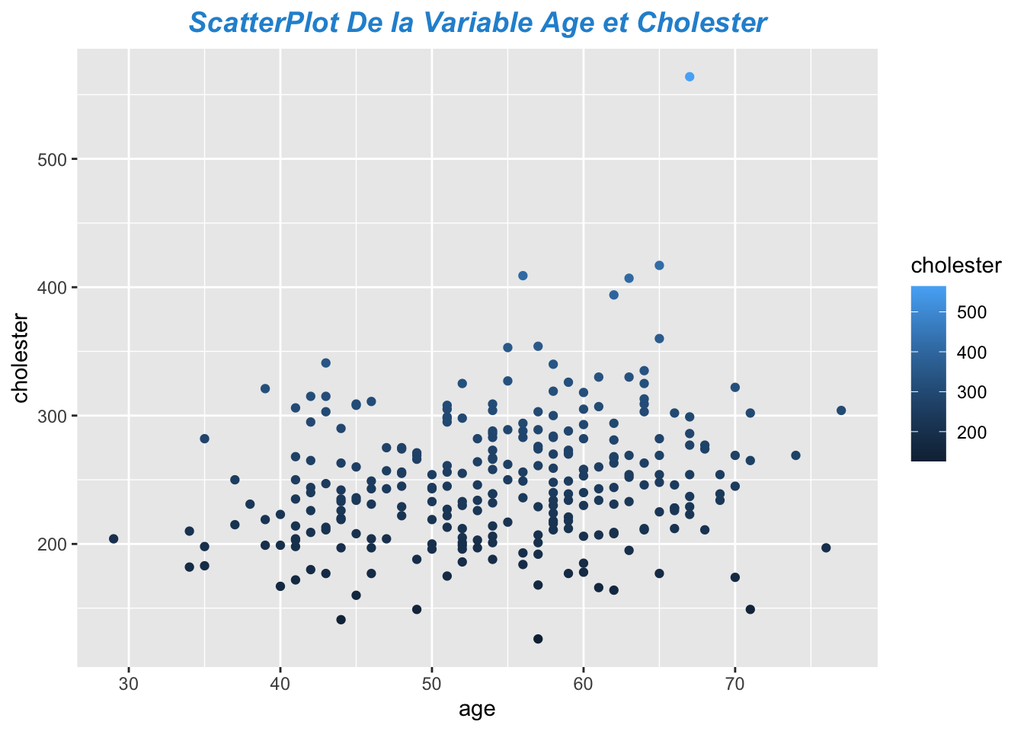

```r
ggplot(bd)+aes(x=age,y=cholester, color = cholester)+geom_point() + ggtitle("ScatterPlot De la Variable Age et Cholester") + theme(
plot.title = element_text(color="#2692D4", size=14, face="bold.italic", hjust = 0.5))
```

Interprétation : Le nuage de points montre une tendance linéaire positive entre les deux variables, lorsque l’age augmente, le taux de cholesterole augmente.

**16- Appliquer un modèle linéaire simple pour expliquer la variable cholesterol en fonction de la variable age.**

Application du modèle :

```r
reg=lm(bd$cholester ~ bd$age)
```

**Afficher le résultat et interpréter**

Affichage du résultat :

```r
summary(reg)
```

```
##
## Call:
## lm(formula = bd$cholester ~ bd$age)
##
## Residuals:
##      Min       1Q   Median       3Q      Max
## -126.864  -34.233   -3.756   28.697  298.650
##
## Coefficients:
##             Estimate Std. Error t value Pr(>|t|)
## (Intercept) 181.6920    18.6593   9.737  < 2e-16 ***
## bd$age        1.2486     0.3381   3.693 0.000269 ***
## ---
## Signif. codes:  0 '***' 0.001 '**' 0.01 '*' 0.05 '.' 0.1 ' ' 1
##
## Residual standard error: 50.51 on 268 degrees of freedom
## Multiple R-squared:  0.04842,    Adjusted R-squared:  0.04487
## F-statistic: 13.64 on 1 and 268 DF,  p-value: 0.0002686
```

Interprétation :

Pour commencer, nous devons évaluer la significativité globale du modèle qui se traduit par une p-value < 0.05 de notre f-statistic (statistique de Fischer). On constate ici que la P-value de notre f-statitic est largement inférieure à 0.05 ce qui nous ocnduit a rejetter l’hypothèse H0 d’absence de significativité des variables et de conclure que notre modèle est globalement significatif.

Par la suite, nous pouvons analyser la significativité de nos coefficients, notre constante et notre variable explicative (Age) a travers l’interpretation de la p-value de celles-ci. Nous pouvons constater que la P-value est largement inférieur à 0.05 (***) ce qui nous permet de rejetter l’hypothèse H0 d’absence de significativité des variables et de conclure que nos coefficients sont significatifs.

En ce qui concerne l’analyse de la qualité de notre modèle, ont peut se référer à notre R2 (Multiple R squared) pour notre modèle vu que c’est une regression linéaire simple. Sur ce point, notre R2 est trés proche de 0 ce qui signifie que notre modèle est de mauvaise qualité et présente un pouvoir explicatif trés faible.

Pour le pouvoir prédictif, nous pouvons jetter un oeil sur l’erreur-type (std error) de notre Constante (intercept) qui présente une valeur plus ou moins élevée (18.6592), IDEM pour notre écart-type résiduel (50.51), ce qui signifie que le pouvoir prédictif n’est pas trés stable sur ce modèle non plus.

Pour conclure, nous pouvons dire que notre modèle n’est pas vraiment un bon modèle pour pouvoir prédire le taux de cholestérol en fonction de l’age avec le jeu de données qu’on possède, vu la qualité du modèle qui est médiocre, et le faible pouvoir prédictif qu’il présente.

**Afficher les coefficients de ce modèle**

```r
coefficients(reg)
```

```
## (Intercept)      bd$age
##  181.691994    1.248633
```

Notre Constante à une valeur de 181.691994 La valeur estimée de la variable age et de : 1.248633

Ce qui signifie que lorque l’age augmente d’une unité, le taux de cholesterol augmente de 1.248633 unités.

**19- Ajouter la ligne de ce modèle sur le graphique du nuage de points**

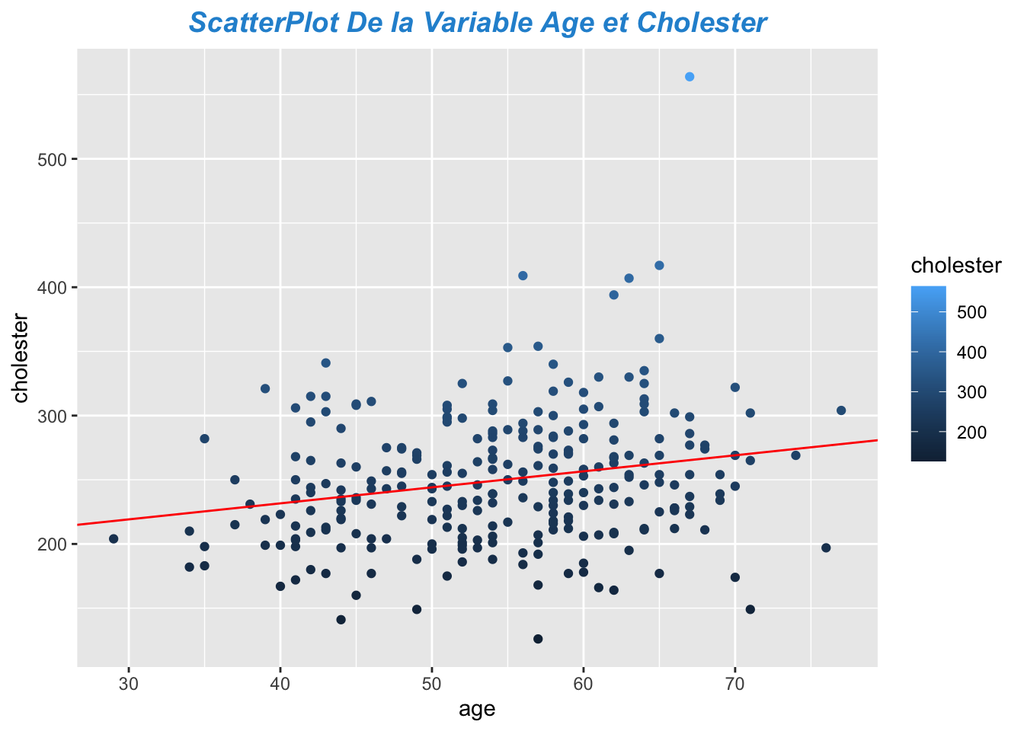

```r
ggplot(bd)+aes(x=age,y=cholester, color = cholester)+geom_point() + ggtitle("ScatterPlot De la Variable Age et Cholester") + theme(
plot.title = element_text(color="#2692D4", size=14, face="bold.italic", hjust = 0.5)) + geom_abline(slope = 1.248633, intercept = 181.691994, color = "red")
```

## Etude des variables “Type_douleur” et “Pression”

**20- Calculer les indicateurs statistiques usuels de la variable quantitative pression( moyenne, mediane, quartiles, min, max et mode)**

```r
summary(bd$pression)
```

```
##    Min. 1st Qu.  Median    Mean 3rd Qu.    Max.
##    94.0   120.0   130.0   131.3   140.0   200.0
```

```r
effectifs<-table(bd$pression)
sort(effectifs)
```

```
##
## 101 104 106 117 123 129 144 146 148 155 156 158 165 172 174 192 200  94 102 170
##   1   1   1   1   1   1   1   1   1   1   1   1   1   1   1   1   1   2   2   2
## 178 105 115 122 126 136 142 180 100 134 152 124 145 108 132 135 118 112 128 138
##   2   3   3   3   3   3   3   3   4   4   4   5   5   6   6   6   7   9   9   9
## 125 160 110 150 140 130 120
##  10  11  17  17  30  31  34
```

Nous pouvons conctater que le mode de la variable pression est : 120

**21- Représenter graphiquement la variable pression par deux représentations différents. Interpréter**

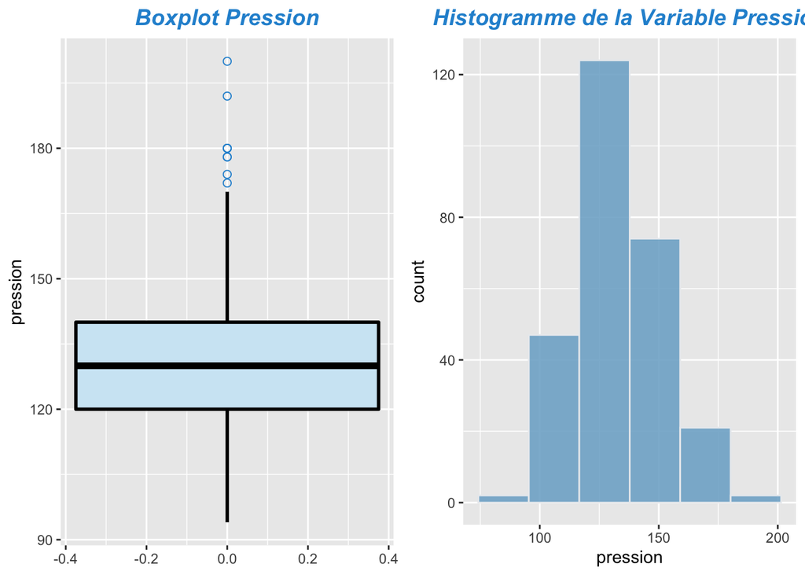

```r
boxplot1 <- ggplot(bd, aes(x=pression)) + coord_flip() +
  geom_boxplot(size = 1, outlier.colour="#2692D4", outlier.shape=1,
  outlier.size=2, fill='#D0E8F5', color="black") + ggtitle("Boxplot Pression") + theme(
plot.title = element_text(color="#2692D4", size=14, face="bold.italic", hjust = 0.5))

hist3 <- ggplot(bd)+aes(x=pression)+geom_histogram(bins=6, fill="#80B1CF", color="#e9ecef", alpha=0.9) +
    ggtitle("Histogramme de la Variable Pression") + theme(
plot.title = element_text(color="#2692D4", size=14, face="bold.italic", hjust = 0.5))

grid.arrange(boxplot1,hist3,ncol=2)
```

**22- Calculer la moyenne de la variable quantitative pression pour chaque groupe (modalité) de la variable type_douleur. Comparer ces moyennes et interpréter.**

```r
tapply(bd$pression,bd$type_douleur,mean)
```

```
##        A        B        C        D
## 141.3000 128.2619 129.5570 131.8992
```

La moyenne du taux de pression du Type de douleur A est de 141.3000 | La moyenne du taux de pression du Type de douleur B est de 128.2619 | La moyenne du taux de pression du Type de douleur C est de 129.5570 | La moyenne du taux de pression du Type de douleur D est de 131.8992

**23- Représenter graphiquement la relation pression sur la base de type_douleur.**

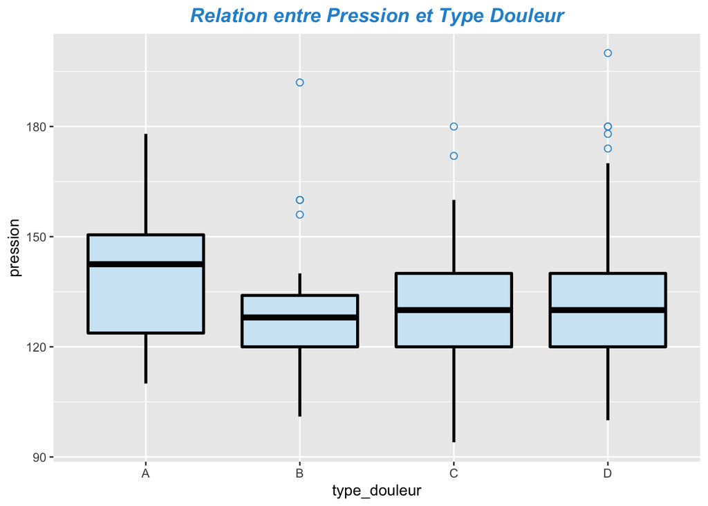

```r
Boxplot2 <- ggplot(bd, aes(x=pression,y=type_douleur)) + coord_flip() +
  geom_boxplot(size = 1, outlier.colour="#2692D4", outlier.shape=1,
  outlier.size=2, fill='#D0E8F5', color="black") + ggtitle("Relation entre Pression et Type Douleur") + theme(
plot.title = element_text(color="#2692D4", size=14, face="bold.italic", hjust = 0.5))

Boxplot2
```

Nous pouvons constater que les distributions sont sont légèrement differentes pour chaque type de douleur surtout pour les valeurs minimales et maximales (ce qui n’est pas trop le cas pour les valeurs médianes), et qu’il existe des valeurs aberrantes pour les types de douleur B, C et D.

**24- Appliquer le test ANOVA pour expliciter ce lien. Ce test servira en quoi ? Afficher le résultat et interpréter.**

Application du test ANOVA :

```r
tes <- aov(bd$pression~bd$type_douleur)
summary(tes)
```

```
##                  Df Sum Sq Mean Sq F value Pr(>F)
## bd$type_douleur   3   2673   891.2   2.851 0.0378 *
## Residuals       266  83148   312.6
## ---
## Signif. codes:  0 '***' 0.001 '**' 0.01 '*' 0.05 '.' 0.1 ' ' 1
```

Le TEST ANOVA (analysis of variance) va nous permettre d’analyser la relation entre une variable qualitative (type_douleur) et une variable quantitative continue (pression) qui suit une loi normale. Ce test consiste a valider ou rejetter l’hypothèse H0 qui conclut l’absence de l’effet de la variable qualitative sur la variable quantitative. Ce test est interpreté a travers la P-value qui doit etre < 0.05 pour rejetter H0 et constater un eventuel effet de la variable qualitative sur la variable quantitative.

Dans notre cas, la P-value est légèrement inférieure à 0.05 ce qui signifie qu’on rejette H0, pour conclure qu’il existe un effet de la variable type douleur sur la variable pression.

## Modélisation linéaire de la variable « pression en fonction de la variable cholesterol ».

**25- Quel type de représentation graphique permet de montrer le liens entre ces deux variable? Le graphique montre-t-il une relation linéaire ?**

Pour étudier le lien entre deux variables quatitatives, nous devons créer un nuage de points qui va permettre d’identifier si il existe une correlation entre les deux variables ou pas.

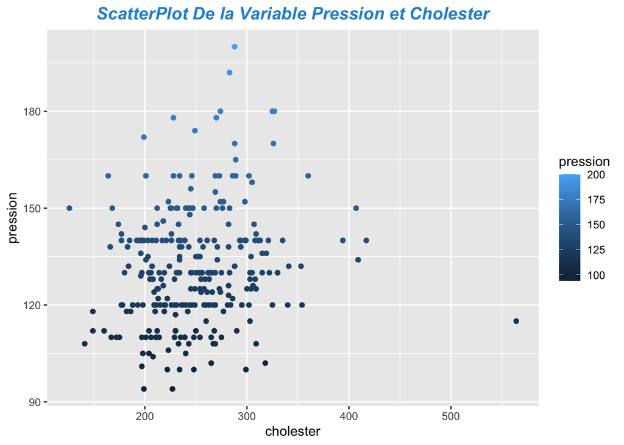

```r
ggplot(bd)+aes(x=cholester,y=pression, color = pression)+geom_point() + ggtitle("ScatterPlot De la Variable Pression et Cholester") + theme(
plot.title = element_text(color="#2692D4", size=14, face="bold.italic", hjust = 0.5))
```

D’aprés le graphique, nous pouvons constater qu’il existe une légère corrélation postivie entre les deux variables.

**26- Appliquer une régression linéaire simple pour expliquer la variable pression en fonction de la variable cholesterol**

Régression linéaire :

```r
reg2=lm(bd$pression ~ bd$cholester)
summary(reg2)
```

```
##
## Call:
## lm(formula = bd$pression ~ bd$cholester)
##
## Residuals:
##     Min      1Q  Median      3Q     Max
## -35.990 -11.260  -1.903  10.334  66.363
##
## Coefficients:
##               Estimate Std. Error t value Pr(>|t|)
## (Intercept)  116.41693    5.30037  21.964  < 2e-16 ***
## bd$cholester   0.05979    0.02079   2.876  0.00435 **
## ---
## Signif. codes:  0 '***' 0.001 '**' 0.01 '*' 0.05 '.' 0.1 ' ' 1
##
## Residual standard error: 17.63 on 268 degrees of freedom
## Multiple R-squared:  0.02994,    Adjusted R-squared:  0.02632
## F-statistic:  8.27 on 1 and 268 DF,  p-value: 0.004354
```

**26- Evaluer la qualité de la modélisation**

En ce qui concerne l’analyse de la qualité de notre modèle, ont peut se référer à notre R2 (Multiple R squared) pour étudier la qualité prédictive et la p-value du F-statistics pour évaluer la significativité globale du modèle. Nous pouvons constater que la P-value de notre F-statistics << 0.05 ce qui signifie que notre modèle et globalement significatif par contre notre R2 est trés proche de 0 soit 0,02994 ce qui signifie que notre modèle est de mauvaise qualité et présente un pouvoir explicatif trés faible.

**27- Ajouter la ligne qui explicite ce modèle sur le graphique du nuage de points ainsi que le texte de l’équation linéaire.**

Affichage des coefficients pour tracer la droite d’ajustement :

```r
coefficients(reg2)
```

```
##  (Intercept) bd$cholester
## 116.41692790   0.05979156
```

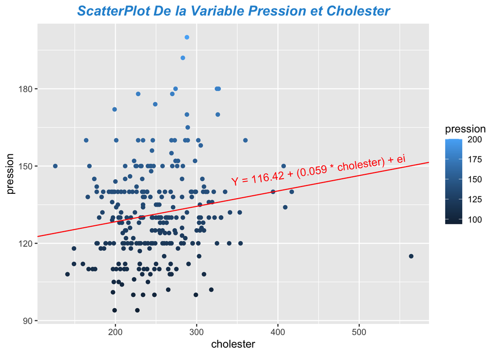

```r
ggplot(bd)+aes(x=cholester,y=pression, color = pression)+geom_point() + ggtitle("ScatterPlot De la Variable Pression et Cholester") + theme(
plot.title = element_text(color="#2692D4", size=14, face="bold.italic", hjust = 0.5)) + geom_abline(slope = 0.05979156, intercept = 116.41692790, color = "red",)+
  annotate(
    "text",
    x = 450,
    y = 6 * 22.5* 1.1,
    angle = 8,
    label = "Y = 116.42 + (0.059 * cholester) + ei",
    color = "Red"
  )
```